# An Interference Model of Visual Working Memory: Applications to Change Detection

April 9, 2018

## From Recall to Recognition

- Many of the "famous" visual-working memory models are recall model.
  - Slot-averaging model.
  - Variable-precision model.
  - Interference model.
- However, models for change-detection task are rare.
- Luckily, someone fixed the problem.
- Let's look at the task first.

## Change-Detection Task

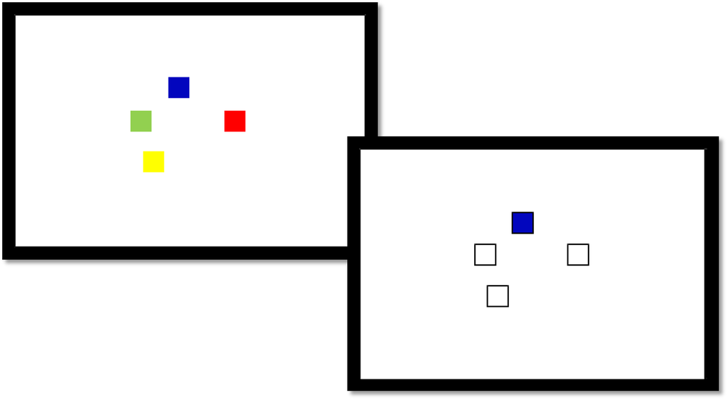

## Change-Detection Task

- 20 participants from UZH
- Material: Colors from continuous colorwheel.
- Manipulations: Set sizes (1-6) and probe type (same, change)
- 2640 trials per participants.

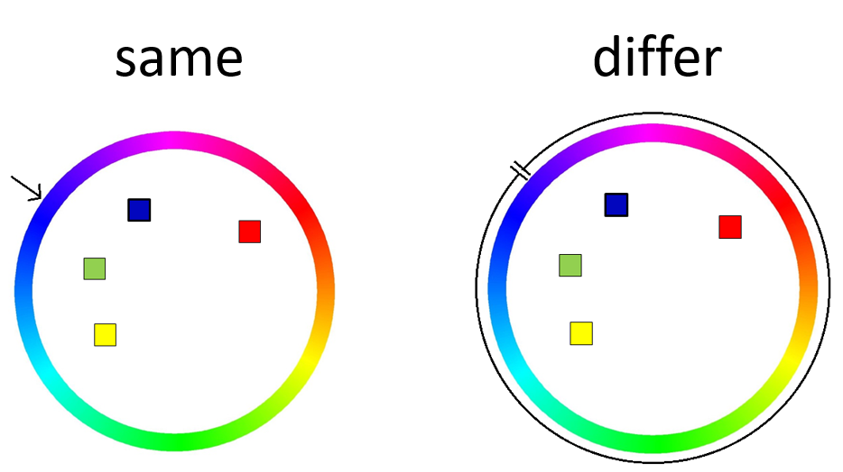

## Results

Set-size effect

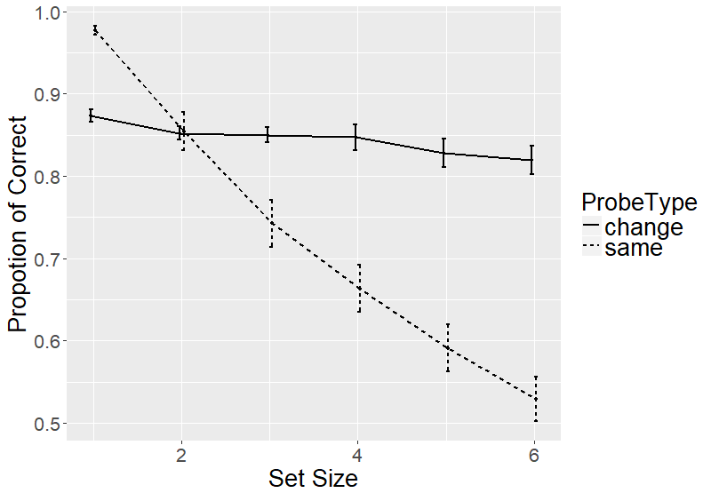

Similarity gradient

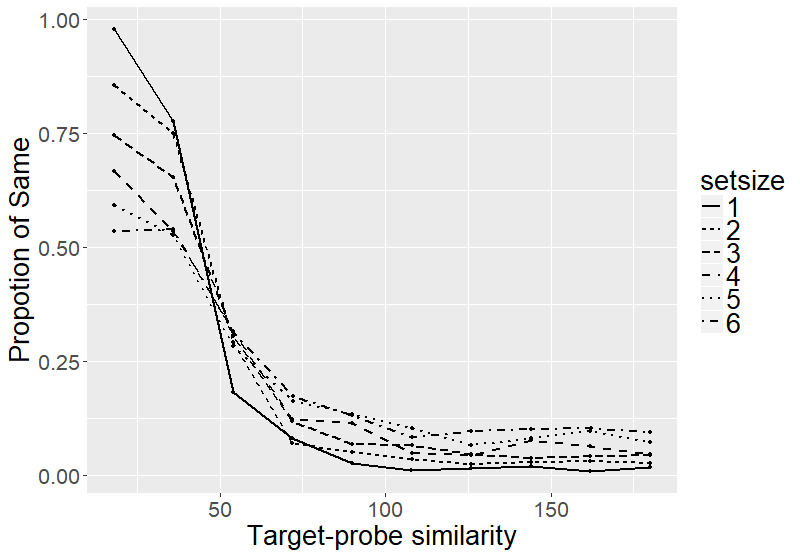

## Bayesian Inference (Keshvari, van den Berg, & Ma, 2013)

\[ d(x, \varphi) = \log[\frac{p("change"|x, \varphi)}{p("same"|x, \varphi)}] \\ = \log[\frac{p(x, \varphi|"change")\cdot p("change")}{p(x, \varphi|"same")\cdot p("same")}]\]

\(x\): Retrieved instance at the probed location. \(\varphi\): color of the probe.

- Respond "change" if d > 0.
- "same" otherwise.

\[ P_{change}(\varphi) = \int [d(x, \varphi) > 0] \cdot P_{recall}(x)\]

## Bayesian Inference

\[ P_{change}(\varphi) = \int [d(x, \varphi) > 0] \cdot P_{recall}(x)\]

[figure not shown]

## Bayesian Inference

\[ P_{change}(\varphi) = \int [d(x, \varphi) > 0] \cdot P_{recall}(x)\]

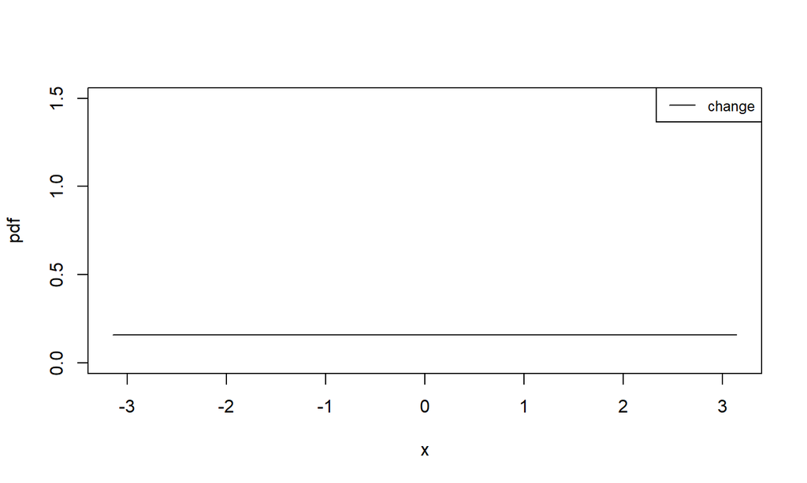

## Bayesian Inference

\[ P_{change}(\varphi) = \int [d(x, \varphi) > 0] \cdot P_{recall}(x)\]

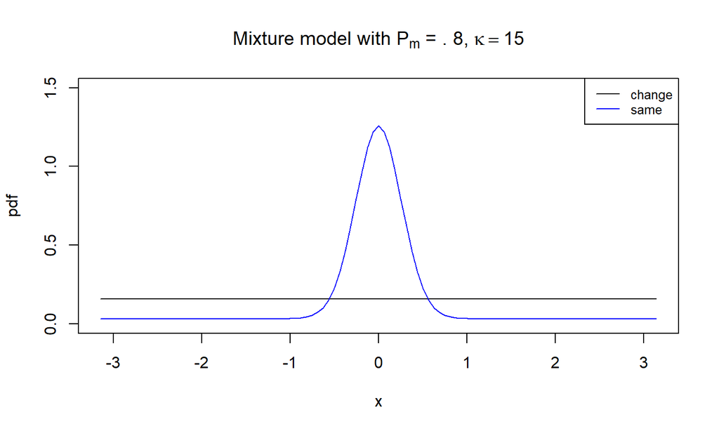

## Bayesian Inference

\[ P_{change}(\varphi) = \int [d(x, \varphi) > 0] \cdot P_{recall}(x)\]

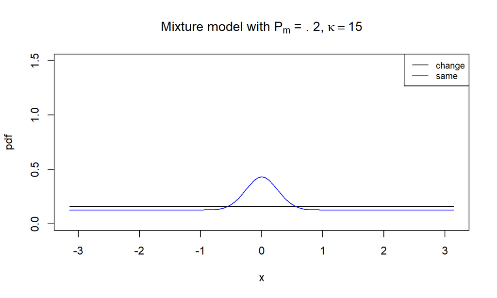

## Bayesian Inference

\[ P_{change}(\varphi) = \int [d(x, \varphi) > 0] \cdot P_{recall}(x)\]

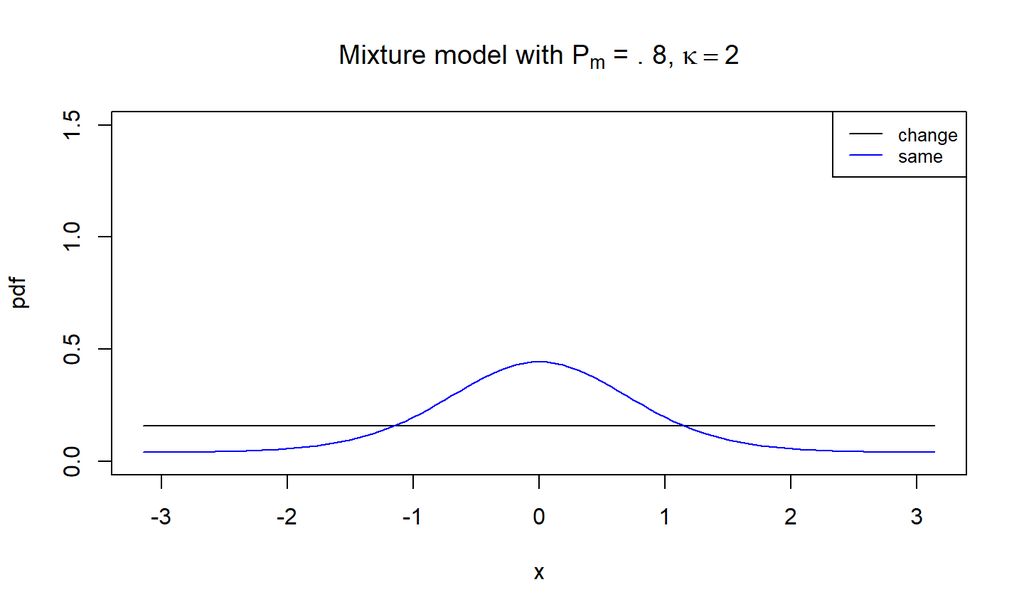

## Interference Model

- Recall process activate all the possible response candidates.
- The response candidates compete with each others.
- Larger activation results in higher probability of being recalled.
- The activation of a candidate is calculated as:

\[ A(x|L_\theta) = a A_a(x) + bA_b(x) + cA_c(x|L_\theta)\]

- The activation (\(A\)) of the response candidate (\(x\)) when location \(\theta\) (\(L_\theta\))is probesd is the combination of three activation (\(A_a\), \(A_b\), and \(A_c\)) with their corresponding weights (\(a\), \(b\), and \(c\)).

## Interfernce Model

\[A(x|L_\theta) = a \color{red}{A_a(x)} + bA_b(x) + cA_c(x|L_\theta)\]

- Activation from context-independent source.
- Activated by recently experienced items regardless the location of probe and the location of items.

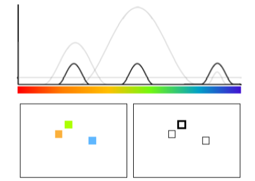

## Interfernece Model

\[A(x|L_\theta) = a A_a(x) + b\color{red}{A_b(x)} + cA_c(x|L_\theta)\]

- Background-noise activation.
- Byproduct of the encoding process.
- Every response candidate received the same background-noise activation.

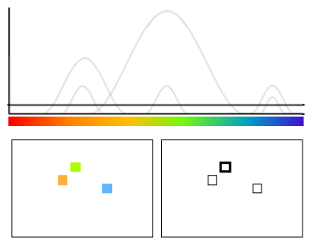

## Interference Model

\[A(x|L_\theta) = a A_a(x) + bA_b(x) + c\color{red}{A_c(x|L_\theta)}\]

- Cued-retrieval activation.
- Activated by reactivate the location-color binding formed during the encoding process.

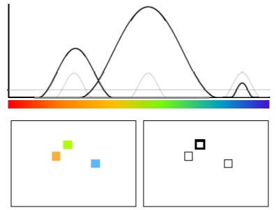

## Interference Model

\[A(x|L_\theta) = a A_a(x) + bA_b(x) + c\color{red}{A_c(x|L_\theta)}\]

- Cued-retrieval activation.
- Activated by reactivate the location-color binding formed during the encoding process.

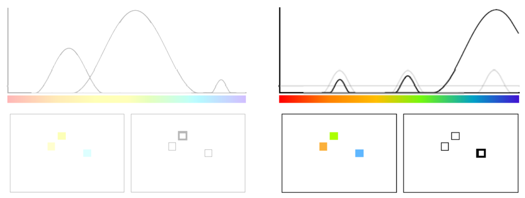

## Interference Model

- That's all!
- Except of "focus of attention".
- Interference comes from:
  - Cued retrieval.
  - Competition between response candidates.
- Chance of getting into focus of attention reduced when set size increases.

## Result

- IM predicts the interference from non-target items.
- Recagegorized probes into:

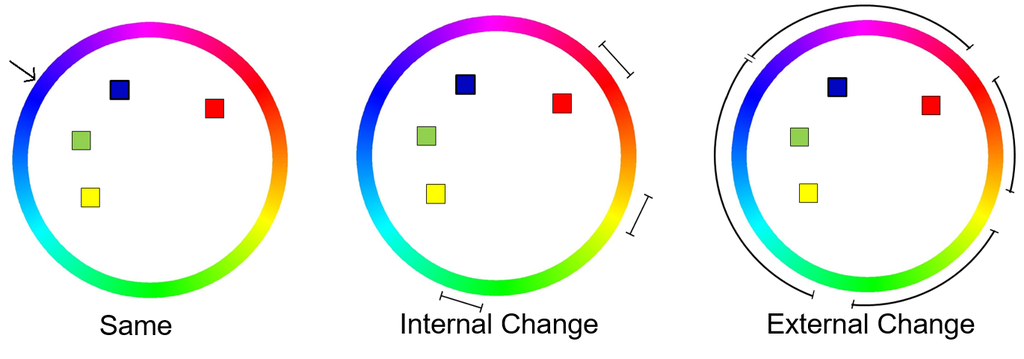

## Recategorized results

Set-size effect

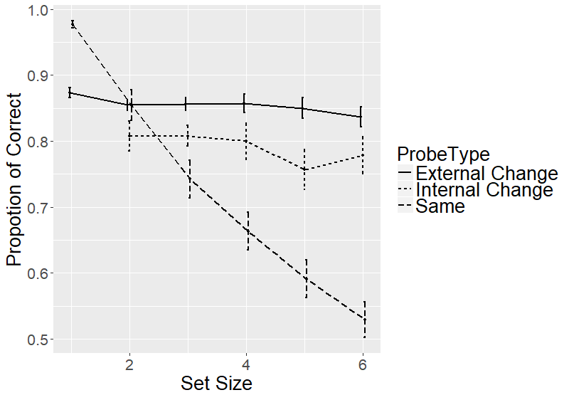

## IM Prediction

Set-size effect

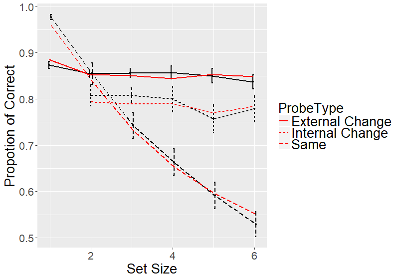

Similarity gradient

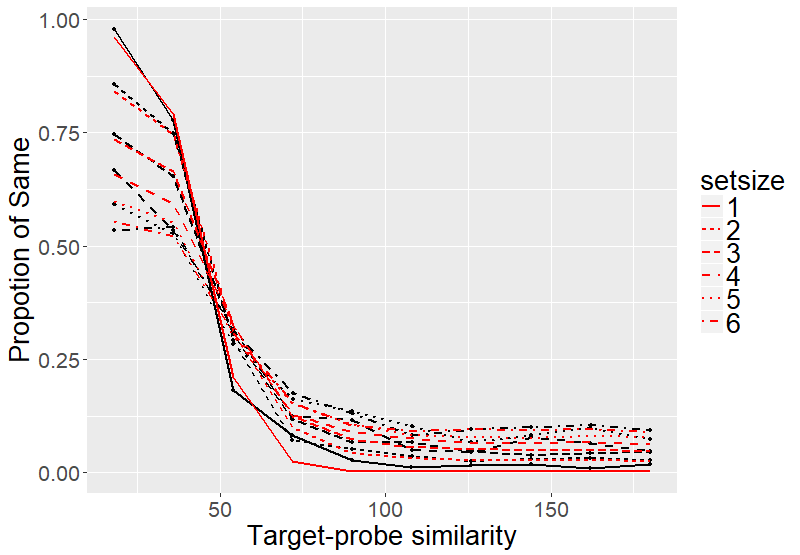

## IM Prediction

Set-size effect

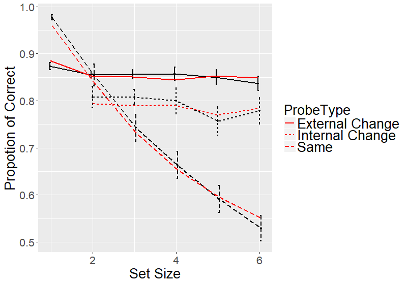

Similarity gradient

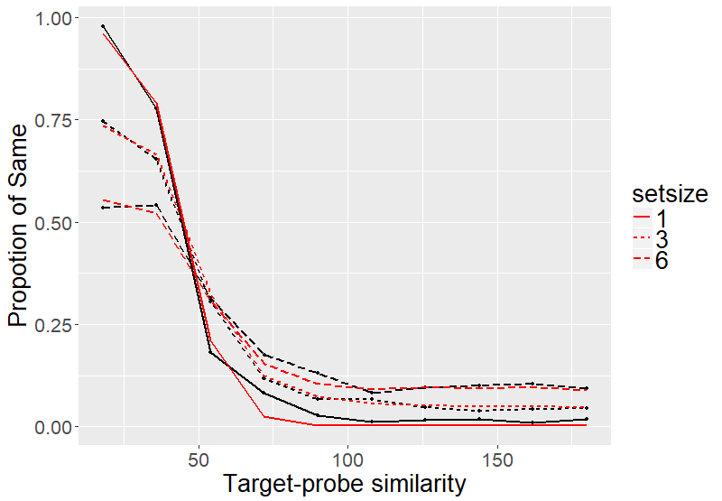

## Slot-averaging Model

Set-size effect

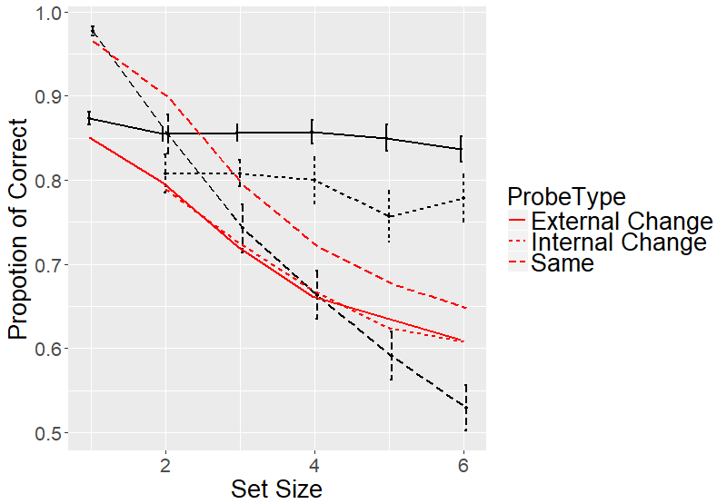

Similarity gradient

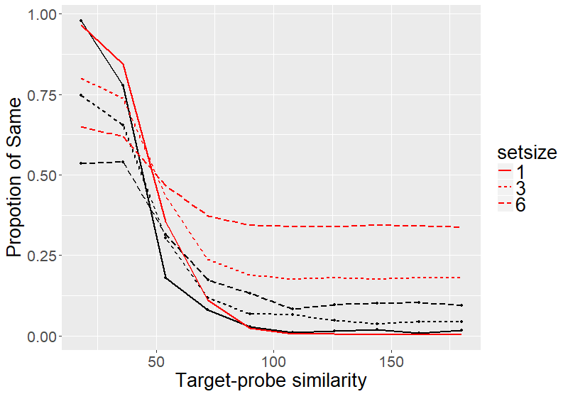

## Variable Percision Model

Set-size effect

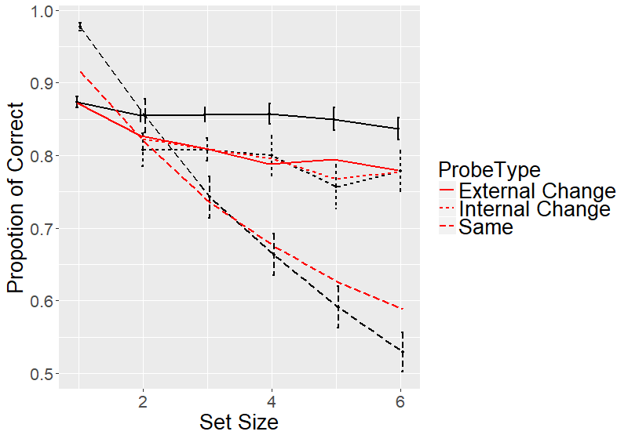

Similarity gradient

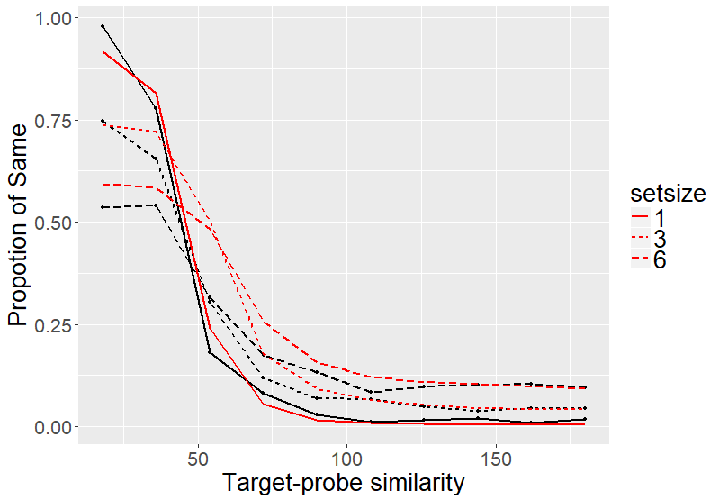

## So That Happened

- SA and VP performed really poorly.
- Let's help them a bit.

## SA-Swap

- Swap could happen between items.
- Probability of swap happening increases with set-sizes.

Set-size effect

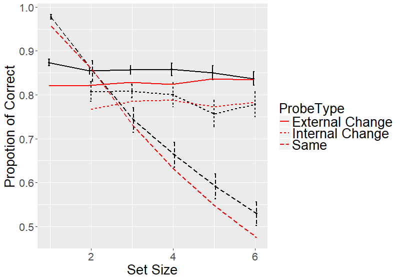

Similarity gradient

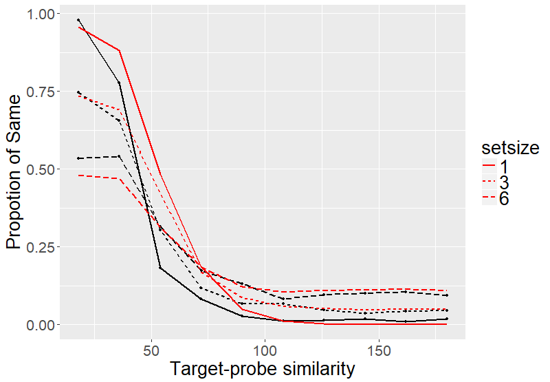

## VP-Binding

- Assumes color-location binding.
- Resources allocated to an item also determines the strength of binding.

Set-size effect

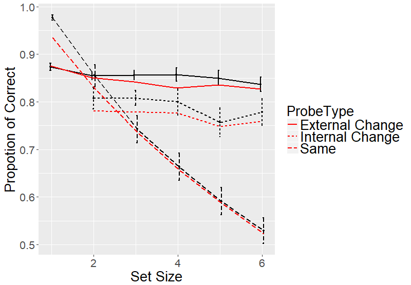

Similarity gradient

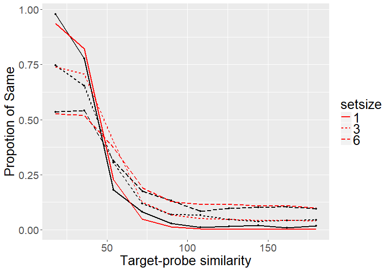

## Conclusion

- IM still owns SA and VP.
  - Even after adding extra assumptions to SA and VP.
- However, inference rule has some issues.
  - The amount of knowledge involved in the inference rule.

## Knowledge in Inference Rule

- Inference rule knows the memory state of the target.

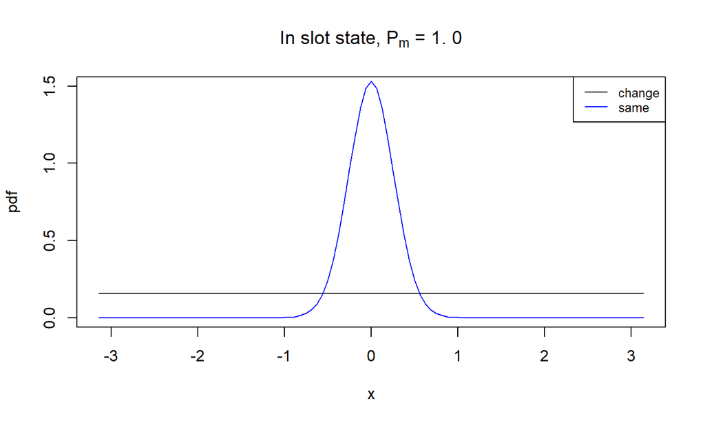

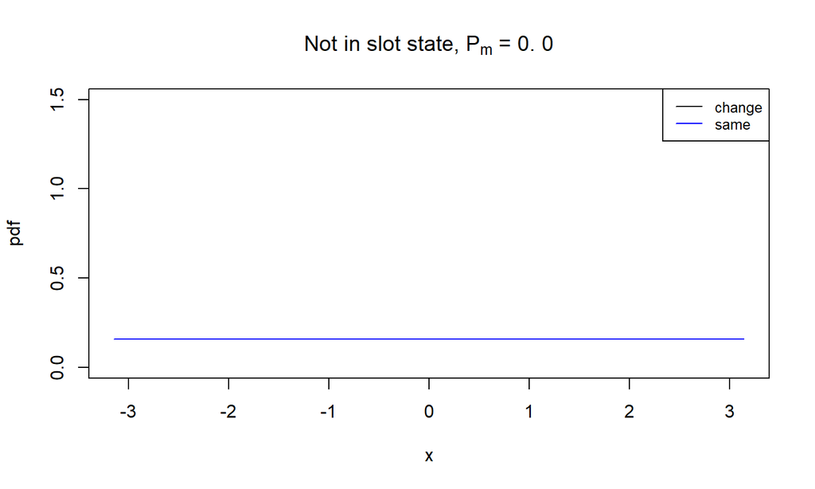